# Lending Club Interest Predictor

```python
import json
import psycopg2
import pandas as pd
import numpy as np
```

## Loading the Data

```python
#Establish connection to PostgresSQL database
with open('config.json') as f:
    conf = json.load(f)
conn_str = "host={} dbname={} user={} password={}".format(conf['host'], conf['database'], conf['user'], conf['passw'])
conn = psycopg2.connect(conn_str)
```

```python
#Read loanstats_2017 table as a dataframe
orig_df = pd.read_sql('SELECT * FROM loanstats', con=conn)
```

```python
orig_df['grade'].unique()
```

```
array(['B', 'C', 'A', 'D', 'G', 'E', 'F'], dtype=object)
```

```python
orig_df.shape
```

```
(235629, 153)
```

We have 235629 entries and 153 attributes

## Data Exploration/ Wrangling

```python
orig_df.head(5)
```

|  | id | member_id | loan_amnt | funded_amnt | funded_amnt_inv | term | int_rate | installment | grade | sub_grade | ... | disbursement_method | debt_settlement_flag | debt_settlement_flag_date | settlement_status | settlement_date | settlement_amount | settlement_percentage | settlement_term | year | quater |
| --- | --- | --- | --- | --- | --- | --- | --- | --- | --- | --- | --- | --- | --- | --- | --- | --- | --- | --- | --- | --- | --- |
| 0 | 37327458 |  | 10000 | 10000 | 10000 | 36 months | 11.99% | 332.1 | B | B5 | ... | Cash | N |  |  |  |  |  |  | 2014 |  |
| 1 | 37790389 |  | 7500 | 7500 | 7500 | 36 months | 14.99% | 259.96 | C | C5 | ... | Cash | N |  |  |  |  |  |  | 2014 |  |
| 2 | 37298010 |  | 5000 | 5000 | 4975 | 36 months | 10.49% | 162.49 | B | B3 | ... | Cash | N |  |  |  |  |  |  | 2014 |  |
| 3 | 37760228 |  | 6000 | 6000 | 6000 | 36 months | 10.49% | 194.99 | B | B3 | ... | Cash | N |  |  |  |  |  |  | 2014 |  |
| 4 | 37770374 |  | 35000 | 35000 | 34975 | 36 months | 10.49% | 1137.43 | B | B3 | ... | Cash | N |  |  |  |  |  |  | 2014 |  |

5 rows × 153 columns

Columns contain data on application, loan information, credit and post-funding payment history.

We will start with exploring following features:

1. loan_amnt
2. purpose
3. application_type
4. annual_inc
5. emp_length
6. home_ownership
7. fico_range_low and fico_range_high (average of these two boundaries)

Let's work through our list of attributes slice-by-slice and figure out what we really need. This involves dropping some useless attributes and cleaning-up/modifying others.

```python
orig_df.iloc[:4,:12]
```

|  | id | member_id | loan_amnt | funded_amnt | funded_amnt_inv | term | int_rate | installment | grade | sub_grade | emp_title | emp_length |
| --- | --- | --- | --- | --- | --- | --- | --- | --- | --- | --- | --- | --- |
| 0 | 37327458 |  | 10000 | 10000 | 10000 | 36 months | 11.99% | 332.1 | B | B5 | Clerk of Court | 4 years |
| 1 | 37790389 |  | 7500 | 7500 | 7500 | 36 months | 14.99% | 259.96 | C | C5 | Staff Accountant | 2 years |
| 2 | 37298010 |  | 5000 | 5000 | 4975 | 36 months | 10.49% | 162.49 | B | B3 | Sr. Facilitator | 4 years |
| 3 | 37760228 |  | 6000 | 6000 | 6000 | 36 months | 10.49% | 194.99 | B | B3 | Program Management Analyst | 10+ years |

```python
#Get the type of applications
orig_df['application_type'].unique()
```

```
array(['Individual'], dtype=object)
```

We will be focusing on Individual loans only for our study instead of Joint Application. Joint Application loans use different credit model, so pooling two application types together will lead to miscalculated targets

```python
#Drop from the dataframe rows that have 'application_type' value different than "Individual"
df = orig_df.drop(orig_df[orig_df['application_type'] != 'Individual'].index)
print ("We've eleminated {} rows".format(orig_df.size - df.size))
df.drop('application_type',1, inplace=True)
```

```
We've eleminated 0 rows
```

```python
df.info()
```

```
<class 'pandas.core.frame.DataFrame'>
Int64Index: 235629 entries, 0 to 235628
Columns: 152 entries, id to quater
dtypes: object(152)
memory usage: 275.0+ MB
```

```python
#Sometimes the null values in this dataSet are not as NaN(pandas null value), but they are actually a string like 'n/a', 'NONE', 'null', 'NULL'
#Replacing them by NaN, so pandas can detect that we have a null value

df.replace({'N/A':np.NaN,'n/a':np.NaN, '':np.NaN, ' ':np.NaN}, inplace=True)
df.replace({'NONE':np.NaN,'none':np.NaN}, inplace=True)
df.replace({'NULL':np.NaN,'null':np.NaN, 'nan':np.NaN}, inplace=True)
```

```python
df.columns[df.isna().any()].tolist()
```

```
['member_id',
 'emp_title',
 'emp_length',
 'description',
 'mths_since_last_delinq',
 'mths_since_last_record',
 'revol_util',
 'last_pymnt_d',
 'next_pymnt_d',
 'last_credit_pull_d',
 'mths_since_last_major_derog',
 'annual_inc_joint',
 'dti_joint',
 'verification_status_joint',
 'open_acc_6m',
 'open_act_il',
 'open_il_12m',
 'open_il_24m',
 'mths_since_rcnt_il',
 'total_bal_il',
 'il_util',
 'open_rv_12m',
 'open_rv_24m',
 'max_bal_bc',
 'all_util',
 'inq_fi',
 'total_cu_tl',
 'inq_last_12m',
 'avg_cur_bal',
 'bc_open_to_buy',
 'bc_util',
 'mo_sin_old_il_acct',
 'mths_since_recent_bc',
 'mths_since_recent_bc_dlq',
 'mths_since_recent_inq',
 'mths_since_recent_revol_delinq',
 'num_tl_120dpd_2m',
 'percent_bc_gt_75',
 'revol_bal_joint',
 'sec_app_fico_range_low',
```

[output cut: 17 more lines]

```
 'hardship_end_date',
 'payment_plan_start_date',
 'hardship_length',
 'hardship_dpd',
 'hardship_loan_status',
 'orig_projected_additional_accrued_interest',
 'hardship_payoff_balance_amount',
 'hardship_last_payment_amount',
 'debt_settlement_flag_date',
 'settlement_status',
 'settlement_date',
 'settlement_amount',
 'settlement_percentage',
 'settlement_term',
 'quater']
```

```python
df.info()
```

```
<class 'pandas.core.frame.DataFrame'>
Int64Index: 235629 entries, 0 to 235628
Columns: 152 entries, id to quater
dtypes: float64(32), object(120)
memory usage: 275.0+ MB
```

```python
#df = df.dropna()
```

We won't need "id" and "member_id" as they have no predictive power, so we can drop them from this table

```python
df.drop(['id','member_id'],1, inplace=True)
```

Let's get list of unique values in the "term" column

```python
#Get List of unique values in the 'term' column
df['term'].unique()
```

```
array([' 36 months', ' 60 months'], dtype=object)
```

"term" columns was loaded as an object data type. Let's strip the string "months" out, remove spaces and convert it to an integerer

```python
#Replace 'term' column by valid values
df['term'] = df['term'].map({' 36 months':'36', ' 60 months':'60'})
#convert to numeric
df['term'] = pd.to_numeric(df['term'])
```

```python
df['term'].unique()
```

```
array([36, 60], dtype=int64)
```

```python
#Check for null values
(df['term'].isnull()).value_counts()
```

```
False    235629
Name: term, dtype: int64
```

No null values present

Let's get list of unique values in the "int_rate" column

```python
#Get list of unique values in 'int_rate' column
df['int_rate'].unique()
```

```
array([' 11.99%', ' 14.99%', ' 10.49%', '  7.49%', ' 13.66%', ' 14.31%',
       ' 12.39%', ' 11.44%', ' 15.59%', '  6.03%', '  6.99%', '  8.19%',
       ' 25.83%', '  8.67%', ' 17.86%', ' 21.99%', ' 12.99%', '  6.49%',
       ' 25.57%', ' 16.49%', ' 24.50%', ' 19.99%', '  9.49%', ' 24.99%',
       ' 25.89%', ' 19.24%', ' 15.99%', ' 20.99%', ' 18.54%', ' 17.14%',
       ' 25.80%', ' 23.99%', ' 22.99%', ' 25.99%', '  6.00%', ' 26.06%',
       ' 16.99%', ' 11.67%', ' 12.49%', ' 18.24%', ' 15.61%', ' 18.99%',
       ' 16.29%', ' 13.35%', ' 19.52%', ' 14.49%', ' 10.99%', ' 23.43%',
       '  8.39%', '  9.17%', ' 13.98%', ' 10.15%', ' 20.20%', ' 17.57%',
       '  7.69%', ' 22.15%', '  7.12%', ' 24.08%', ' 16.59%', ' 15.31%',
       ' 19.47%', ' 14.16%', ' 17.50%', ' 13.65%', ' 14.64%', ' 21.18%',
       '  9.67%', '  8.90%', '  7.62%', ' 18.25%', '  7.90%', '  6.62%',
       ' 22.45%', ' 20.49%', ' 18.92%', ' 16.24%', ' 14.47%', ' 23.70%',
       ' 21.48%', ' 12.85%', ' 19.22%', ' 14.98%', ' 19.97%', ' 13.53%',
       ' 20.50%', ' 22.90%', ' 23.40%', ' 22.40%', ' 19.20%'],
      dtype=object)
```

"int_rate" was loaded as an object data type. Let's strip the '%' character, remove spaces in the column values and convert the column type to float

```python
#Remove '%' character
df['int_rate'].replace(to_replace='%', value='', inplace=True, regex=True)
#Remove spaces
df['int_rate'].replace(to_replace='\s+', value='', inplace=True, regex=True)
#Convert to numeric
df['int_rate'] = pd.to_numeric(df['int_rate'])
print (df['int_rate'].dtype)
df['int_rate'].unique()
```

```
float64
```

```
array([11.99, 14.99, 10.49,  7.49, 13.66, 14.31, 12.39, 11.44, 15.59,
        6.03,  6.99,  8.19, 25.83,  8.67, 17.86, 21.99, 12.99,  6.49,
       25.57, 16.49, 24.5 , 19.99,  9.49, 24.99, 25.89, 19.24, 15.99,
       20.99, 18.54, 17.14, 25.8 , 23.99, 22.99, 25.99,  6.  , 26.06,
       16.99, 11.67, 12.49, 18.24, 15.61, 18.99, 16.29, 13.35, 19.52,
       14.49, 10.99, 23.43,  8.39,  9.17, 13.98, 10.15, 20.2 , 17.57,
        7.69, 22.15,  7.12, 24.08, 16.59, 15.31, 19.47, 14.16, 17.5 ,
       13.65, 14.64, 21.18,  9.67,  8.9 ,  7.62, 18.25,  7.9 ,  6.62,
       22.45, 20.49, 18.92, 16.24, 14.47, 23.7 , 21.48, 12.85, 19.22,
       14.98, 19.97, 13.53, 20.5 , 22.9 , 23.4 , 22.4 , 19.2 ])
```

```python
#Check for null values
(df['int_rate'].isnull()).value_counts()
```

```
False    235629
Name: int_rate, dtype: int64
```

No null values present

Let's get list of unique values in the "loan_amnt" column

```python
##Get List of unique values in the 'loan_amnt' column
df['loan_amnt'].unique()
```

```
array(['10000', '7500', '5000', ..., '1225', '30650', '32325'],
      dtype=object)
```

"loan_amnt" was loaded as an object. Let's convert it to numeric

```python
#convert 'loan_amnt' to numeric
df['loan_amnt'] = pd.to_numeric(df['loan_amnt'])
df['loan_amnt'].dtype
```

```
dtype('int64')
```

```python
df['loan_amnt'].unique()
```

```
array([10000,  7500,  5000, ...,  1225, 30650, 32325], dtype=int64)
```

```python
#Check for null values
(df['loan_amnt'].isnull()).value_counts()
```

```
False    235629
Name: loan_amnt, dtype: int64
```

No null values present

In the data dictonary "loan_amnt" is the listed amount of the loan applied for by the borrower. **If at some point in time, the credit department reduces the loan amount, then it will be reflected in this value.** and the "funded_amnt" is the total amount committed to that loan at that point in time

That means that in our data the "loan_amnt" and "funded_amnt" columns will have the same values since the data has already been manipulated.

Let's confirm with the code

```python
df['funded_amnt'] = pd.to_numeric(df['funded_amnt'])
(df['loan_amnt'] != df['funded_amnt']).value_counts()
```

```
False    235629
dtype: int64
```

We notice that loan_amnt and funded_amnt columns have the exact same value, so we can drop one of them

```python
#Dropping the funded_amnt column
df.drop(['funded_amnt'],1, inplace=True)
```

Let's keep moving trough the columns

```python
df.iloc[:5,7:20]
```

|  | emp_title | emp_length | home_ownership | annual_inc | verification_status | issue_d | loan_status | pymnt_plan | url | description | purpose | title | zip_code |
| --- | --- | --- | --- | --- | --- | --- | --- | --- | --- | --- | --- | --- | --- |
| 0 | Clerk of Court | 4 years | MORTGAGE | 75000 | Source Verified | Dec-2014 | Charged Off | n | https://lendingclub.com/browse/loanDetail.acti... | NaN | home_improvement | Home improvement | 441xx |
| 1 | Staff Accountant | 2 years | RENT | 32000 | Not Verified | Dec-2014 | Fully Paid | n | https://lendingclub.com/browse/loanDetail.acti... | NaN | debt_consolidation | Debt consolidation | 801xx |
| 2 | Sr. Facilitator | 4 years | RENT | 48600 | Source Verified | Dec-2014 | Fully Paid | n | https://lendingclub.com/browse/loanDetail.acti... | NaN | debt_consolidation | Debt consolidation | 282xx |
| 3 | Program Management Analyst | 10+ years | MORTGAGE | 69220 | Verified | Dec-2014 | Fully Paid | n | https://lendingclub.com/browse/loanDetail.acti... | NaN | debt_consolidation | Debt consolidation | 302xx |
| 4 | Assistant Superintendent | 3 years | MORTGAGE | 121200 | Verified | Dec-2014 | Fully Paid | n | https://lendingclub.com/browse/loanDetail.acti... | NaN | debt_consolidation | Debt consolidation | 730xx |

emp_title feature - Possibly employment titles are bucketted by industries/fields, which is helpful for managing the risk of loan portfolios. However we will not be using this feature for this project.

```python
df.drop(['emp_title'],1, inplace=True)
```

```python
#Check for null values in emp_length
(df['emp_length'].isnull()).value_counts()
```

```
False    223610
True      12019
Name: emp_length, dtype: int64
```

```python
#Get unique values
df['emp_length'].unique()
```

```
array(['4 years', '2 years', '10+ years', '3 years', '< 1 year', nan,
       '8 years', '1 year', '7 years', '9 years', '6 years', '5 years'],
      dtype=object)
```

"emp_length" column was loaded as an object data type. Let's strip the special characters, fill the null values with zeroes and change the data type to integer

```python
#fill null values with 1
df['emp_length'].fillna(value=0,inplace=True)
```

```python
#remove special characters
df['emp_length'].replace(to_replace='[^0-9]+', value='', inplace=True, regex=True)
#Convert emp_length to numerical
df['emp_length'] = df['emp_length'].astype(int)
df['emp_length'].unique()
```

```
array([ 4,  2, 10,  3,  1,  0,  8,  7,  9,  6,  5], dtype=int64)
```

```python
(df['emp_length'].isnull()).value_counts()
```

```
False    235629
Name: emp_length, dtype: int64
```

Let's get all unique values in "home_ownership" column

```python
df['home_ownership'].unique()
```

```
array(['MORTGAGE', 'RENT', 'OWN', 'ANY'], dtype=object)
```

```python
#Replace nan value
df['home_ownership'].fillna(value='ANY',inplace=True)
```

```python
(df['home_ownership'].isnull()).value_counts()
```

```
False    235629
Name: home_ownership, dtype: int64
```

Let's get all unique values in "annual_inc" column

```python
df['annual_inc'].unique()
```

```
array(['75000', '32000', '48600', ..., '45175', '83450', '59482'],
      dtype=object)
```

The column is loaded as an object, let's convert it to numeric

```python
#Convert annual_inc to numeric
df['annual_inc'] = pd.to_numeric(df['annual_inc'])
df['annual_inc'].unique()
```

```
array([75000., 32000., 48600., ..., 45175., 83450., 59482.])
```

```python
#Check for null values
(df['annual_inc'].isnull()).value_counts()
```

```
False    235629
Name: annual_inc, dtype: int64
```

No null values present

Let's get all unique values in verification_status column

```python
df['verification_status'].unique()
```

```
array(['Source Verified', 'Not Verified', 'Verified'], dtype=object)
```

'Source Verified', and 'verified' values don't make a lot of sense. The data dictionary is not explainig the difference betwee the two

```python
#df.drop(['verification_status'],1, inplace=True)
```

Dropping "loan_status" column, cause our focus is to predict the interest rate granted to an applicant at **loan creation**. The same for "pymnt_plan"

```python
df.drop(['loan_status','pymnt_plan'],1, inplace=True)
```

Moving on to the next slice of columns

```python
df.iloc[:5,15:25]
```

|  | title | zip_code | addr_state | dti | delinq_2yrs | earliest_cr_line | fico_range_low | fico_range_high | inq_last_6mths | mths_since_last_delinq |
| --- | --- | --- | --- | --- | --- | --- | --- | --- | --- | --- |
| 0 | Home improvement | 441xx | OH | 21.5 | 1 | May-1983 | 670 | 674 | 0 | 9 |
| 1 | Debt consolidation | 801xx | CO | 36.83 | 0 | Jun-2009 | 730 | 734 | 1 | NaN |
| 2 | Debt consolidation | 282xx | NC | 13.23 | 0 | Aug-2006 | 665 | 669 | 0 | 62 |
| 3 | Debt consolidation | 302xx | GA | 17.98 | 0 | Sep-1983 | 670 | 674 | 1 | NaN |
| 4 | Debt consolidation | 730xx | OK | 29.76 | 0 | Sep-1992 | 695 | 699 | 1 | NaN |

Let's get all unique values in purpose column

```python
df['purpose'].unique()
```

```
array(['home_improvement', 'debt_consolidation', 'credit_card',
       'small_business', 'other', 'major_purchase', 'car', 'vacation',
       'moving', 'house', 'medical', 'renewable_energy', 'wedding'],
      dtype=object)
```

```python
#Check for null values
(df['purpose'].isnull()).value_counts()
```

```
False    235629
Name: purpose, dtype: int64
```

No null values present

Let's get all unique values in 'description'

```python
df['description'].unique()
```

```
array([nan,
       'Looking to borrow to purchase a used boat we are interested in',
       'I support myself and my mother and have taken on debt to assist with her bills and health care needs. I would like to pay down debt faster through refinancing at a lower rate.',
       ...,
       '  Borrower added on 12/09/13 > consolidate all credit accounts<br>',
       '  Borrower added on 12/06/13 > I am going to consolidate a credit card debt from medical and moving expenses with a loan I already have. I have paid everything on time for years, I just need to eliminate this high interest credit card.<br>',
       '  Borrower added on 12/04/13 > I will like a loan to fix  our cars and paid our house property tax<br>'],
      dtype=object)
```

```python
df.drop(['description','url','year'],1, inplace=True)
```

```python
df['delinq_2yrs'].unique()
```

```
array(['1', '0', '2', '4', '3', '5', '6', '12', '8', '9', '7', '10', '21',
       '14', '11', '22', '13', '15', '19', '16', '17', '18'], dtype=object)
```

"delinq_2yrs" variable contains the number of 30+ days past-due incidences of delinquency in the borrower's credit file for the past 2 years

```python
#Check for null values in delinq_2yrs column
(df['delinq_2yrs'].isnull()).value_counts()
```

```
False    235629
Name: delinq_2yrs, dtype: int64
```

```python
#Convert delinq_2yrs to numeric
df['delinq_2yrs'] = pd.to_numeric(df['delinq_2yrs'])
df['delinq_2yrs'].unique()
```

```
array([ 1,  0,  2,  4,  3,  5,  6, 12,  8,  9,  7, 10, 21, 14, 11, 22, 13,
       15, 19, 16, 17, 18], dtype=int64)
```

"earliest_cr_line" variable has information on the date the borrower's earliest reported credit line was opened. It is currently an object. We will convert it to a scalar to describe the length of time since the first line of credit.

```python
#Check for null values
(df['earliest_cr_line'].isnull()).value_counts()
```

```
False    235629
Name: earliest_cr_line, dtype: int64
```

Convert date to number of days

```python
from datetime import datetime
df['earliest_cr_line'] = pd.to_datetime(df['earliest_cr_line'])
dttoday = pd.Timestamp( datetime.now().strftime('%Y-%m-%d')  )
df['earliest_cr_line'] = ( dttoday - df['earliest_cr_line'] ) / np.timedelta64(1, 'D')
```

Let's get all unique values in 'fico_range_low'' column

```python
df['fico_range_low'].unique()
```

```
array(['670', '730', '665', '695', '660', '745', '725', '685', '710',
       '780', '715', '675', '705', '755', '700', '775', '720', '750',
       '690', '830', '680', '765', '740', '770', '760', '735', '805',
       '795', '800', '845', '810', '790', '785', '820', '815', '825',
       '835', '840'], dtype=object)
```

```python
#Convert fico low to numeric
df['fico_range_low'] = pd.to_numeric(df['fico_range_low'])
df['fico_range_low'].dtype
```

```
dtype('int64')
```

```python
#Check for null values
(df['fico_range_low'].isnull()).value_counts()
```

```
False    235629
Name: fico_range_low, dtype: int64
```

Let's get all unique values in fico_range_high column

```python
df['fico_range_high'].unique()
```

```
array(['674', '734', '669', '699', '664', '749', '729', '689', '714',
       '784', '719', '679', '709', '759', '704', '779', '724', '754',
       '694', '834', '684', '769', '744', '774', '764', '739', '809',
       '799', '804', '850', '814', '794', '789', '824', '819', '829',
       '839', '844'], dtype=object)
```

```python
#Convert fico high to numeric
df['fico_range_high'] = pd.to_numeric(df['fico_range_high'])
```

```python
#Check for null values
(df['fico_range_high'].isnull()).value_counts()
```

```
False    235629
Name: fico_range_high, dtype: int64
```

The FICO fico_range_low and fico_range_high scores on their own aren't as useful as a range and average. Let's create to new variables

```python
df['fico_range'] = df['fico_range_low'].astype('str') + '-' + df['fico_range_high'].astype('str')
df['meanfico'] = ( df['fico_range_low'] + df['fico_range_high'] ) / 2
df.drop(['fico_range_high','fico_range_low'],1, inplace=True)
```

```python
df['last_fico_range_low'] = pd.to_numeric(df['last_fico_range_low'])
df['last_fico_range_high'] = pd.to_numeric(df['last_fico_range_high'])
df['last_fico_range'] = df.last_fico_range_low.astype('str') + '-' + df.last_fico_range_high.astype('str')
df['last_meanfico'] = (df.last_fico_range_low + df.last_fico_range_high)/2
df.drop(['last_fico_range_high','last_fico_range_low','policy_code'],1, inplace=True)
```

Let's take a look at 'revol_util' variable

It's the revolving line utilization rate, or the amount of credit the borrower is using relative to all available revolving credit.

```python
df['revol_util'].unique()
```

```
array(['73.4%', '16.5%', '27.3%', ..., '111.3%', '113%', '141.8%'],
      dtype=object)
```

```python
(df['revol_util'].isnull()).value_counts()
```

```
False    235504
True        125
Name: revol_util, dtype: int64
```

```python
#Remove '%' character
df['revol_util'].replace(to_replace='%', value='', inplace=True, regex=True)
#Convert to numeric
df['revol_util'] = pd.to_numeric(df['revol_util'])
print (df['revol_util'].unique())
(df['revol_util'].isnull()).value_counts()
```

```
[ 73.4  16.5  27.3 ... 111.3 113.  141.8]
```

```
False    235504
True        125
Name: revol_util, dtype: int64
```

```python
df['revol_util'].fillna(value=0.0,inplace=True)
```

```python
(df['revol_util'].isnull()).value_counts()
```

```
False    235629
Name: revol_util, dtype: int64
```

```python
df.drop('quater',1,inplace = True)
```

```python
df.drop(['out_prncp','out_prncp_inv','total_pymnt',
         'total_pymnt_inv','total_rec_prncp', 'sub_grade'] ,1, inplace=True)

df.drop(['total_rec_int','total_rec_late_fee',
         'recoveries','collection_recovery_fee',
         'collection_recovery_fee' ],1, inplace=True)

df.drop(['last_pymnt_d','last_pymnt_amnt',
         'next_pymnt_d','last_credit_pull_d'],1, inplace=True)

df.drop(['zip_code','funded_amnt_inv', 'installment', 'mths_since_last_delinq', 'total_acc'], axis=1, inplace=True)

df.drop(['settlement_status', 'settlement_date', 'settlement_amount', 'settlement_percentage', 'settlement_term', 'debt_settlement_flag',
         'debt_settlement_flag_date'],axis=1, inplace = True)

df.drop(['hardship_amount', 'hardship_dpd', 'hardship_end_date', 'hardship_flag', 'hardship_last_payment_amount', 'hardship_length',
        'hardship_loan_status' , 'hardship_payoff_balance_amount', 'hardship_reason', 'hardship_start_date', 'hardship_status',
        'hardship_type'],axis=1, inplace = True)

df.drop(['payment_plan_start_date','deferral_term'],axis=1, inplace = True)
```

Delete fields about joint applications, since it's out of scope of our study

```python
df.drop(['sec_app_chargeoff_within_12_mths', 'sec_app_collections_12_mths_ex_med', 'sec_app_earliest_cr_line',
         'sec_app_fico_range_high', 'sec_app_fico_range_low', 'sec_app_inq_last_6mths', 'sec_app_mort_acc',
         'sec_app_mths_since_last_major_derog', 'sec_app_num_rev_accts', 'sec_app_open_acc',
         'sec_app_open_act_il', 'sec_app_revol_util']
        ,axis=1, inplace = True)

df.drop(['verification_status_joint'], axis=1, inplace = True)
df.drop(['revol_bal_joint'], axis=1, inplace = True)
df.drop(['annual_inc_joint'], axis=1, inplace = True)
df.drop(['dti_joint'], axis=1, inplace = True)
```

```python
#'addr_state' feature is the state provided by the borrower in loan application
(df['addr_state'].isnull()).value_counts()
```

```
False    235629
Name: addr_state, dtype: int64
```

'dti' feature is a ratio calculated using the borrower’s total monthly debt payments on the total debt obligations, excluding mortgage and the requested LC loan, divided by the borrower’s self-reported monthly income.

```python
#'dti' feature
(df['dti'].isnull()).value_counts()
```

```
False    235629
Name: dti, dtype: int64
```

```python
df['dti'].unique()
```

```
array(['21.5', '36.83', '13.23', ..., '0.15', '0.03', '0.43'],
      dtype=object)
```

```python
#Convert dti column to numeric
df['dti'] = pd.to_numeric(df['dti'])
df['dti'].dtype
```

```
dtype('float64')
```

'inq_last_6mths' feature is the number of inquiries in past 6 months (excluding auto and mortgage inquiries)

```python
(df['inq_last_6mths'].isnull()).value_counts()
```

```
False    235629
Name: inq_last_6mths, dtype: int64
```

```python
df['inq_last_6mths'].unique()
```

```
array(['0', '1', '2', '3', '4', '5', '6'], dtype=object)
```

```python
#Convert to numeric
df['inq_last_6mths'] = pd.to_numeric(df['inq_last_6mths'])
df['inq_last_6mths'].dtype
```

```
dtype('int64')
```

'open_acc' is the number of open credit lines in the borrower's credit file

```python
(df['open_acc'].isnull()).value_counts()
```

```
False    235629
Name: open_acc, dtype: int64
```

```python
#Convert to numeric
df['open_acc'] = pd.to_numeric(df['open_acc'])
df['open_acc'].dtype
```

```
dtype('int64')
```

```python
df['open_acc'].unique()
```

```
array([11, 17, 10, 13, 26, 20,  5, 16, 24,  8, 30,  9, 23,  6,  7, 19, 29,
       15, 12, 21, 18, 14, 25,  4, 22, 28, 27,  3, 35, 33,  2, 31, 38, 32,
       54, 34, 39, 41, 36, 37, 53,  1, 43, 40, 42, 47, 76, 44, 45, 48, 58,
       50, 52, 55, 84, 75, 46, 51, 49, 61,  0], dtype=int64)
```

```python
#Convert to numeric
df['pub_rec'] = pd.to_numeric(df['pub_rec'])
df['pub_rec'].dtype
df['pub_rec'].unique()
```

```
array([ 2,  0,  1,  4,  3, 12,  5, 18,  6,  7, 10,  8, 11, 19, 16, 15,  9,
       14, 40, 63, 13, 21, 34, 17], dtype=int64)
```

```python
(df['pub_rec'].isnull()).value_counts()
```

```
False    235629
Name: pub_rec, dtype: int64
```

'revol_bal' feature is the total credit revolving balance

```python
df['revol_bal'].unique()
```

```
array(['28862', '3625', '2757', ..., '1298783', '40177', '115671'],
      dtype=object)
```

```python
(df['revol_bal'].isnull()).value_counts()
```

```
False    235629
Name: revol_bal, dtype: int64
```

```python
df['revol_bal'] = pd.to_numeric(df['revol_bal'])
df['revol_bal'].dtype
```

```
dtype('int64')
```

'collections_12_mths_ex_med' is the number of collections in 12 months excluding medical collections

```python
print (df['collections_12_mths_ex_med'].unique() )
(df['collections_12_mths_ex_med'].isnull()).value_counts()
```

```
['0' '1' '2' '3' '4' '6' '16' '20' '5']
```

```
False    235629
Name: collections_12_mths_ex_med, dtype: int64
```

```python
df['collections_12_mths_ex_med'] = pd.to_numeric(df['collections_12_mths_ex_med'])
df['collections_12_mths_ex_med'].dtype
```

```
dtype('int64')
```

```python
(df['issue_d'].isnull()).value_counts()
```

```
False    235629
Name: issue_d, dtype: int64
```

```python
print (df['issue_d'].unique())
df['issue_d'] = pd.to_datetime(df['issue_d'])
```

```
['Dec-2014' 'Nov-2014' 'Oct-2014' 'Aug-2014' 'Sep-2014' 'Jul-2014'
 'Jun-2014' 'May-2014' 'Apr-2014' 'Mar-2014' 'Feb-2014' 'Jan-2014']
```

```python
non_numerical_variales = ['home_ownership', 'purpose', 'title', 'addr_state', 'verification_status', 'initial_list_status', 'disbursement_method',
                        'fico_range', 'last_fico_range','grade','issue_d','earliest_cr_line']

for column in df.columns :
    if column not in non_numerical_variales :
        df[column] = pd.to_numeric(df[column])
```

Let's check if our categorical variables have meaningful categorical data

```python
categorial_variables = ['home_ownership', 'purpose', 'title', 'addr_state', 'initial_list_status', 'disbursement_method',
                        'fico_range', 'last_fico_range','grade']

for column in df.columns :
    if column in categorial_variables :
        print (df[column].value_counts())
```

```
C    66565
B    61935
D    42992
A    36108
E    20121
F     6223
G     1685
Name: grade, dtype: int64
MORTGAGE    119937
RENT         92684
OWN          23007
ANY              1
Name: home_ownership, dtype: int64
debt_consolidation    143006
credit_card            55522
home_improvement       13045
other                  10371
major_purchase          3858
medical                 2331
small_business          2277
car                     1832
moving                  1328
vacation                1178
house                    750
renewable_energy         123
wedding                    8
Name: purpose, dtype: int64
Debt consolidation                          140624
Credit card refinancing                      54347
Home improvement                             12880
Other                                        10230
Major purchase                                3817
Medical expenses                              2303
Business                                      2238
Car financing                                 1809
Moving and relocation                         1319
Vacation                                      1167
Home buying                                    743
Debt Consolidation                             344
Consolidation                                  134
```

[output cut: 190 more lines]

```
805-809    1517
510-514    1448
515-519    1428
505-509    1274
810-814    1196
500-504    1147
815-819     955
820-824     652
825-829     556
830-834     310
835-839     165
840-844      89
0-0          85
845-850      32
Name: last_fico_range, Length: 72, dtype: int64
```

Examining the unique values of purpose and title show that they are lending club selected options;howver, they have almost same values. We will drop one of them. The other catgeorial variables seems to be all lending club selected options.

```python
#Let's drop title column
df.drop('title',1,inplace = True)
```

```python
#Drop columns that have no data at all
columns_to_drop = []
for col in df.columns :
    if len(df[col].value_counts()) == 0 :
        print (col)
        columns_to_drop.append(col)

df.drop(columns_to_drop,1,inplace = True)
```

```python
df.columns[df.isna().any()].tolist()
```

```
['mths_since_last_record',
 'mths_since_last_major_derog',
 'avg_cur_bal',
 'bc_open_to_buy',
 'bc_util',
 'mo_sin_old_il_acct',
 'mths_since_recent_bc',
 'mths_since_recent_bc_dlq',
 'mths_since_recent_inq',
 'mths_since_recent_revol_delinq',
 'num_tl_120dpd_2m',
 'percent_bc_gt_75',
 'orig_projected_additional_accrued_interest']
```

```python
df['mths_since_last_record'].fillna(value=0,inplace=True)
df['mths_since_last_major_derog'].fillna(value=0,inplace=True)
#'avg_cur_bal' is the average current balance off all accounts
(df['avg_cur_bal'].isnull()).value_counts()
#####'bc_open_to_buy' is Total open to buy on revolving bankcards
df['bc_open_to_buy'].fillna(value=0,inplace=True)
#######'bc_util' is Ratio of total current balance to high credit/credit limit for all bankcard accounts.
df['bc_util'].fillna(value=0,inplace=True)
#'mo_sin_old_il_acct' is months since oldest bank installment account opened
df['mo_sin_old_il_acct'].fillna(value=0,inplace=True)
#'mths_since_recent_bc' is Months since most recent bankcard account opened
df['mths_since_recent_bc'].fillna(value=0,inplace=True)
#''mths_since_recent_bc_dlq' is Months since most recent bankcard delinquency
df['mths_since_recent_bc_dlq'].fillna(value=0,inplace=True)
#'mths_since_recent_inq' is Months since most recent inquiry
df['mths_since_recent_inq'].fillna(value=0,inplace=True)
#mths_since_recent_revol_delinq is Months since most recent revolving delinquency
df['mths_since_recent_revol_delinq'].fillna(value=0,inplace=True)
#'num_tl_120dpd_2m' is Number of accounts currently 120 days past due (updated in past 2 months)
df['num_tl_120dpd_2m'].fillna(value=0,inplace=True)
#'percent_bc_gt_75' is Percentage of all bankcard accounts > 75% of limit
df['percent_bc_gt_75'].fillna(value=0,inplace=True)
#'orig_projected_additional_accrued_interest' -  has post funding information can be dropped
df.drop('orig_projected_additional_accrued_interest',1,inplace = True)
```

```python
df['avg_cur_bal'].fillna(value=0,inplace=True)
```

```python
# #'avg_cur_bal' is the average current balance off all accounts
# df['avg_cur_bal'].fillna(value=0,inplace=True)


# #####'bc_open_to_buy' is Total open to buy on revolving bankcards
# df['bc_open_to_buy'].fillna(value=0,inplace=True)
# #######'bc_util' is Ratio of total current balance to high credit/credit limit for all bankcard accounts.
# df['bc_util'].fillna(value=0,inplace=True)


# #'mo_sin_old_il_acct' is months since oldest bank installment account opened
# df['mo_sin_old_il_acct'].fillna(value=0,inplace=True)

# #'mths_since_recent_bc' is Months since most recent bankcard account opened
# df['mths_since_recent_bc'].fillna(value=0,inplace=True)
# #''mths_since_recent_bc_dlq' is Months since most recent bankcard delinquency
# df['mths_since_recent_bc_dlq'].fillna(value=0,inplace=True)
# #'mths_since_recent_inq' is Months since most recent inquiry
# df['mths_since_recent_inq'].fillna(value=0,inplace=True)
# #mths_since_recent_revol_delinq is Months since most recent revolving delinquency
# df['mths_since_recent_revol_delinq'].fillna(value=0,inplace=True)
# #'num_tl_120dpd_2m' is Number of accounts currently 120 days past due (updated in past 2 months)
# df['num_tl_120dpd_2m'].fillna(value=0,inplace=True)
# #'percent_bc_gt_75' is Percentage of all bankcard accounts > 75% of limit
# df['percent_bc_gt_75'].fillna(value=0,inplace=True)
# #'orig_projected_additional_accrued_interest' -  has post funding information can be dropped
# df.drop('orig_projected_additional_accrued_interest',1,inplace = True)

# #verify these
# df['mths_since_last_record'].fillna(value=0,inplace=True)
# df['mths_since_last_major_derog'].fillna(value=0,inplace=True)
# df['mths_since_rcnt_il'].fillna(value=0,inplace=True)
# df['il_util'].fillna(value=0,inplace=True)
# df['all_util'].fillna(value=0,inplace=True)
```

```python
df.columns[df.isna().any()].tolist()
```

```
[]
```

Save the work to a sql database file

```python
import pandas.io.sql as pd_sql
import sqlite3 as sql

# Create a sqlite3 database to store the data.
con  = sql.connect('mydb.db')

pd_sql.to_sql(df, "loanstats_2017", con)
```

# Our Model

```python
#import necessary libraries
import os
import pandas as pd
import numpy as np
import matplotlib.pyplot as plt
import seaborn as sns
import pandas.io.sql as pd_sql
import sqlite3 as sql
import requests
import json

from pandas.plotting import scatter_matrix

from sklearn.linear_model import LinearRegression, Ridge, SGDRegressor, Lasso, ElasticNet
from sklearn.ensemble import RandomForestRegressor
from sklearn.feature_selection import SelectFromModel

from sklearn.metrics import r2_score
from sklearn.metrics import mean_squared_error as mse
from sklearn.model_selection import train_test_split
from sklearn.preprocessing import LabelEncoder, OneHotEncoder

%matplotlib inline
```

Let's load our wrangled data from sqlite database with Pandas

```python
def load_data() :
    con  = sql.connect('mydb.db')
    data_frame = pd_sql.read_sql('select * from loanstats_2017', con, index_col='index').reset_index()
    data_frame.drop('index',axis=1, inplace=True)

    return data_frame

orig_df = load_data()
orig_df.head(2)
```

|  | loan_amnt | term | int_rate | grade | emp_length | home_ownership | annual_inc | verification_status | issue_d | purpose | ... | tax_liens | tot_hi_cred_lim | total_bal_ex_mort | total_bc_limit | total_il_high_credit_limit | disbursement_method | fico_range | meanfico | last_fico_range | last_meanfico |
| --- | --- | --- | --- | --- | --- | --- | --- | --- | --- | --- | --- | --- | --- | --- | --- | --- | --- | --- | --- | --- | --- |
| 0 | 10000 | 36 | 11.99 | B | 4 | MORTGAGE | 75000.0 | Source Verified | 2014-12-01 00:00:00 | home_improvement | ... | 2 | 69592 | 52217 | 33000 | 30292 | Cash | 670-674 | 672.0 | 615-619 | 617.0 |
| 1 | 7500 | 36 | 14.99 | C | 2 | RENT | 32000.0 | Not Verified | 2014-12-01 00:00:00 | debt_consolidation | ... | 0 | 110809 | 95042 | 7000 | 88809 | Cash | 730-734 | 732.0 | 755-759 | 757.0 |

2 rows × 69 columns

```python
orig_df['revol_util'].fillna(value=0.0,inplace=True)
```

Let's structure our data on disk in a way that we can load into Scikit-Learn in a repeatable fashion for continued analysis

```python
#Create meta.json file
meta = {
    'target_names': list(orig_df['int_rate'].unique()),
    'feature_names': list(orig_df.columns),
    'categorical_features': {
        column: list(orig_df[column].unique())
        for column in orig_df.columns
        if orig_df[column].dtype == 'object'
    },
}

with open('data/meta.json', 'w') as f:
    json.dump(meta, f, indent=2)

# Load the meta data from the file
root='data'
with open(os.path.join(root, 'meta.json'), 'r') as f:
    meta = json.load(f)

categorical_features = meta['categorical_features']
```

Let's get a sense for how the "int_rate" variable is distributed

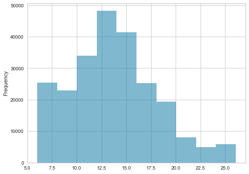

```python
orig_df['int_rate'].plot(kind='hist', alpha=0.5, figsize=(8,6))
```

```python
#Let's examine the dataframes correlation matrix
cor = orig_df.corr().abs()
cor
```

|  | loan_amnt | term | int_rate | emp_length | annual_inc | dti | delinq_2yrs | earliest_cr_line | inq_last_6mths | mths_since_last_record | ... | pct_tl_nvr_dlq | percent_bc_gt_75 | pub_rec_bankruptcies | tax_liens | tot_hi_cred_lim | total_bal_ex_mort | total_bc_limit | total_il_high_credit_limit | meanfico | last_meanfico |
| --- | --- | --- | --- | --- | --- | --- | --- | --- | --- | --- | --- | --- | --- | --- | --- | --- | --- | --- | --- | --- | --- |
| loan_amnt | 1.000000 | 0.403860 | 0.117398 | 0.120163 | 0.391962 | 0.028210 | 0.006276 | 0.176707 | 0.028251 | 0.136044 | ... | 0.114456 | 0.022604 | 0.155027 | 0.002332 | 0.363991 | 0.292025 | 0.405051 | 0.196574 | 0.151096 | 0.088200 |
| term | 0.403860 | 1.000000 | 0.449693 | 0.084485 | 0.063229 | 0.090771 | 0.008148 | 0.047600 | 0.001376 | 0.041554 | ... | 0.050610 | 0.080216 | 0.048019 | 0.011425 | 0.112442 | 0.101358 | 0.067636 | 0.075336 | 0.001355 | 0.059547 |
| int_rate | 0.117398 | 0.449693 | 1.000000 | 0.017167 | 0.083813 | 0.151012 | 0.058963 | 0.080475 | 0.212358 | 0.069292 | ... | 0.088594 | 0.273505 | 0.060033 | 0.030377 | 0.101272 | 0.030979 | 0.228595 | 0.044667 | 0.409601 | 0.303350 |
| emp_length | 0.120163 | 0.084485 | 0.017167 | 1.000000 | 0.098671 | 0.012631 | 0.028500 | 0.135308 | 0.004323 | 0.012166 | ... | 0.030032 | 0.019112 | 0.003848 | 0.011753 | 0.127064 | 0.000530 | 0.065981 | 0.020741 | 0.026844 | 0.020163 |
| annual_inc | 0.391962 | 0.063229 | 0.083813 | 0.098671 | 1.000000 | 0.212005 | 0.054714 | 0.164917 | 0.050120 | 0.063930 | ... | 0.005715 | 0.023508 | 0.077052 | 0.048690 | 0.495968 | 0.375825 | 0.317269 | 0.306357 | 0.110005 | 0.085494 |
| dti | 0.028210 | 0.090771 | 0.151012 | 0.012631 | 0.212005 | 1.000000 | 0.017753 | 0.023136 | 0.009642 | 0.057361 | ... | 0.109039 | 0.159951 | 0.060833 | 0.039975 | 0.006689 | 0.277428 | 0.040262 | 0.314982 | 0.041688 | 0.064261 |
| delinq_2yrs | 0.006276 | 0.008148 | 0.058963 | 0.028500 | 0.054714 | 0.017753 | 1.000000 | 0.090195 | 0.024215 | 0.041799 | ... | 0.445177 | 0.011118 | 0.051333 | 0.012223 | 0.072289 | 0.026845 | 0.074925 | 0.062033 | 0.176480 | 0.057497 |
| earliest_cr_line | 0.176707 | 0.047600 | 0.080475 | 0.135308 | 0.164917 | 0.023136 | 0.090195 | 1.000000 | 0.002056 | 0.054852 | ... | 0.121526 | 0.005946 | 0.067676 | 0.040306 | 0.201871 | 0.103788 | 0.234935 | 0.024869 | 0.094243 | 0.110720 |
| inq_last_6mths | 0.028251 | 0.001376 | 0.212358 | 0.004323 | 0.050120 | 0.009642 | 0.024215 | 0.002056 | 1.000000 | 0.065242 | ... | 0.050021 | 0.086649 | 0.085311 | 0.009706 | 0.031163 | 0.037724 | 0.032205 | 0.059157 | 0.079655 | 0.082383 |
| mths_since_last_record | 0.136044 | 0.041554 | 0.069292 | 0.012166 | 0.063930 | 0.057361 | 0.041799 | 0.054852 | 0.065242 | 1.000000 | ... | 0.023743 | 0.030081 | 0.773414 | 0.166100 | 0.112186 | 0.099236 | 0.184072 | 0.050003 | 0.201533 | 0.056085 |
| open_acc | 0.193133 | 0.073620 | 0.012596 | 0.041618 | 0.150567 | 0.278571 | 0.049458 | 0.123357 | 0.095375 | 0.056689 | ... | 0.132401 | 0.088331 | 0.066751 | 0.012601 | 0.273246 | 0.406788 | 0.329279 | 0.367435 | 0.049064 | 0.021320 |
| pub_rec | 0.109998 | 0.043454 | 0.072051 | 0.009631 | 0.019031 | 0.074501 | 0.021990 | 0.078590 | 0.068295 | 0.665077 | ... | 0.068139 | 0.050289 | 0.631819 | 0.702020 | 0.090447 | 0.082233 | 0.156446 | 0.038179 | 0.196797 | 0.053846 |
| revol_bal | 0.351039 | 0.097783 | 0.025888 | 0.087956 | 0.335988 | 0.129729 | 0.037544 | 0.199878 | 0.034720 | 0.137683 | ... | 0.140776 | 0.101256 | 0.143584 | 0.019291 | 0.465162 | 0.521682 | 0.515214 | 0.105219 | 0.084081 | 0.078692 |
| revol_util | 0.130720 | 0.106301 | 0.244416 | 0.038341 | 0.051061 | 0.165879 | 0.010899 | 0.004910 | 0.101106 | 0.085495 | ... | 0.004712 | 0.671521 | 0.107247 | 0.013224 | 0.036197 | 0.128107 | 0.144579 | 0.047790 | 0.411616 | 0.121827 |
| collections_12_mths_ex_med | 0.016780 | 0.006285 | 0.017446 | 0.006139 | 0.004774 | 0.008947 | 0.039710 | 0.005368 | 0.003315 | 0.004756 | ... | 0.039342 | 0.029416 | 0.008721 | 0.015014 | 0.006454 | 0.012428 | 0.024243 | 0.001257 | 0.056221 | 0.019051 |
| mths_since_last_major_derog | 0.096205 | 0.033113 | 0.073353 | 0.018762 | 0.008693 | 0.053632 | 0.037088 | 0.097019 | 0.079944 | 0.067878 | ... | 0.479658 | 0.018424 | 0.099655 | 0.018785 | 0.051360 | 0.054623 | 0.180440 | 0.009237 | 0.246340 | 0.065189 |
| acc_now_delinq | 0.000134 | 0.003181 | 0.028784 | 0.009172 | 0.018834 | 0.006232 | 0.132465 | 0.026100 | 0.007443 | 0.008249 | ... | 0.051834 | 0.021548 | 0.013240 | 0.004946 | 0.028571 | 0.011849 | 0.005260 | 0.019839 | 0.039216 | 0.005738 |
| tot_coll_amt | 0.003196 | 0.002709 | 0.001454 | 0.002432 | 0.002324 | 0.004506 | 0.000433 | 0.003473 | 0.002276 | 0.000586 | ... | 0.015280 | 0.004582 | 0.000449 | 0.001416 | 0.001111 | 0.001408 | 0.006207 | 0.004477 | 0.010978 | 0.001975 |
| tot_cur_bal | 0.344248 | 0.117375 | 0.070870 | 0.116346 | 0.482394 | 0.020177 | 0.068917 | 0.178801 | 0.031463 | 0.103446 | ... | 0.027753 | 0.018863 | 0.120270 | 0.004003 | 0.976395 | 0.509750 | 0.322139 | 0.390049 | 0.166358 | 0.110279 |
| total_rev_hi_lim | 0.312193 | 0.060943 | 0.139317 | 0.075985 | 0.301211 | 0.065866 | 0.042236 | 0.206497 | 0.008111 | 0.128812 | ... | 0.163577 | 0.124147 | 0.131236 | 0.020986 | 0.459816 | 0.424809 | 0.656509 | 0.084462 | 0.271214 | 0.138750 |
| acc_open_past_24mths | 0.014878 | 0.021817 | 0.168623 | 0.016096 | 0.040379 | 0.157651 | 0.068122 | 0.046458 | 0.220484 | 0.066754 | ... | 0.064994 | 0.126942 | 0.090029 | 0.003985 | 0.075640 | 0.141088 | 0.001623 | 0.178036 | 0.089722 | 0.116183 |
| avg_cur_bal | 0.251675 | 0.090097 | 0.068638 | 0.101766 | 0.380877 | 0.134807 | 0.055635 | 0.129549 | 0.007187 | 0.077451 | ... | 0.037094 | 0.042765 | 0.091318 | 0.001790 | 0.803045 | 0.282378 | 0.156702 | 0.192349 | 0.148972 | 0.105032 |
| bc_open_to_buy | 0.213332 | 0.004117 | 0.289178 | 0.028695 | 0.183211 | 0.062473 | 0.048440 | 0.164243 | 0.004598 | 0.117414 | ... | 0.162869 | 0.421525 | 0.112031 | 0.020295 | 0.254686 | 0.116844 | 0.834043 | 0.041328 | 0.494990 | 0.206011 |
| bc_util | 0.062796 | 0.083118 | 0.259051 | 0.023387 | 0.000988 | 0.167195 | 0.015765 | 0.012489 | 0.084271 | 0.027555 | ... | 0.000459 | 0.828484 | 0.044646 | 0.011625 | 0.013292 | 0.079222 | 0.211781 | 0.025932 | 0.430006 | 0.135189 |
| chargeoff_within_12_mths | 0.000296 | 0.002505 | 0.016759 | 0.005462 | 0.015906 | 0.011073 | 0.132644 | 0.039181 | 0.010702 | 0.018058 | ... | 0.084469 | 0.014630 | 0.020026 | 0.004418 | 0.012653 | 0.001027 | 0.013599 | 0.007518 | 0.053531 | 0.004295 |
| delinq_amnt | 0.000421 | 0.000722 | 0.006190 | 0.005247 | 0.008119 | 0.003451 | 0.028003 | 0.006625 | 0.001348 | 0.000312 | ... | 0.010060 | 0.011489 | 0.001688 | 0.002194 | 0.020178 | 0.005399 | 0.001220 | 0.004455 | 0.006600 | 0.002307 |
| mo_sin_old_il_acct | 0.159354 | 0.083312 | 0.088811 | 0.122006 | 0.155903 | 0.095219 | 0.088916 | 0.344725 | 0.024098 | 0.038175 | ... | 0.096758 | 0.036768 | 0.046393 | 0.012224 | 0.199057 | 0.219480 | 0.089564 | 0.233443 | 0.032804 | 0.060709 |
| mo_sin_old_rev_tl_op | 0.185184 | 0.048701 | 0.097213 | 0.130518 | 0.160006 | 0.028134 | 0.088415 | 0.924248 | 0.004398 | 0.030969 | ... | 0.113390 | 0.014016 | 0.057572 | 0.026758 | 0.203493 | 0.092979 | 0.260690 | 0.006819 | 0.109576 | 0.132358 |
| mo_sin_rcnt_rev_tl_op | 0.073341 | 0.025049 | 0.108862 | 0.014411 | 0.052610 | 0.018400 | 0.041386 | 0.053320 | 0.161422 | 0.062458 | ... | 0.019443 | 0.103896 | 0.076778 | 0.004049 | 0.050924 | 0.039770 | 0.015278 | 0.020333 | 0.103636 | 0.083595 |
| mo_sin_rcnt_tl | 0.042925 | 0.001378 | 0.122302 | 0.010687 | 0.014827 | 0.092021 | 0.031074 | 0.026573 | 0.218760 | 0.051732 | ... | 0.013355 | 0.095215 | 0.061324 | 0.001120 | 0.037064 | 0.061156 | 0.028643 | 0.095136 | 0.076567 | 0.082469 |
| mort_acc | 0.238037 | 0.103429 | 0.042641 | 0.170200 | 0.261368 | 0.065728 | 0.088906 | 0.289596 | 0.056907 | 0.006236 | ... | 0.060817 | 0.016436 | 0.035341 | 0.012493 | 0.516817 | 0.128329 | 0.187124 | 0.084104 | 0.087359 | 0.107174 |
| mths_since_recent_bc | 0.056782 | 0.024660 | 0.075994 | 0.031088 | 0.047818 | 0.004780 | 0.069023 | 0.094452 | 0.104427 | 0.030970 | ... | 0.044194 | 0.153964 | 0.049980 | 0.008830 | 0.056567 | 0.036409 | 0.050928 | 0.019262 | 0.067410 | 0.076017 |
| mths_since_recent_bc_dlq | 0.056865 | 0.016989 | 0.048470 | 0.021321 | 0.006491 | 0.038820 | 0.048827 | 0.099263 | 0.046505 | 0.015240 | ... | 0.428655 | 0.012745 | 0.026611 | 0.022659 | 0.017926 | 0.034827 | 0.130935 | 0.000796 | 0.187582 | 0.040999 |
| mths_since_recent_inq | 0.026939 | 0.002492 | 0.117772 | 0.005590 | 0.023904 | 0.017120 | 0.016983 | 0.004217 | 0.484974 | 0.029338 | ... | 0.030350 | 0.050531 | 0.041383 | 0.006625 | 0.002545 | 0.017185 | 0.013562 | 0.021900 | 0.046301 | 0.043910 |
| mths_since_recent_revol_delinq | 0.051985 | 0.017254 | 0.045192 | 0.020698 | 0.008042 | 0.035681 | 0.009864 | 0.095780 | 0.042920 | 0.011802 | ... | 0.412903 | 0.008718 | 0.026471 | 0.021543 | 0.016634 | 0.031334 | 0.129070 | 0.001879 | 0.192403 | 0.034751 |
| num_accts_ever_120_pd | 0.062891 | 0.022464 | 0.052126 | 0.018947 | 0.024845 | 0.059840 | 0.213996 | 0.108917 | 0.055875 | 0.001866 | ... | 0.545492 | 0.028692 | 0.000914 | 0.016374 | 0.004703 | 0.013035 | 0.145713 | 0.025561 | 0.210005 | 0.042675 |
| num_actv_bc_tl | 0.199215 | 0.056462 | 0.032733 | 0.067679 | 0.111422 | 0.148206 | 0.052474 | 0.116882 | 0.022354 | 0.058388 | ... | 0.141234 | 0.032945 | 0.076732 | 0.008001 | 0.110989 | 0.128330 | 0.455020 | 0.010023 | 0.076900 | 0.018404 |
| num_actv_rev_tl | 0.152439 | 0.064182 | 0.113344 | 0.111480 | 0.068527 | 0.238339 | 0.012940 | 0.148862 | 0.062570 | 0.016467 | ... | 0.100097 | 0.081296 | 0.041454 | 0.003589 | 0.095277 | 0.114383 | 0.259134 | 0.001931 | 0.158639 | 0.068553 |
| num_bc_sats | 0.203919 | 0.039073 | 0.040951 | 0.058180 | 0.127212 | 0.086717 | 0.039912 | 0.143529 | 0.074132 | 0.045377 | ... | 0.126499 | 0.168911 | 0.040927 | 0.001499 | 0.135518 | 0.115734 | 0.554388 | 0.015755 | 0.072952 | 0.035247 |
| num_bc_tl | 0.182083 | 0.033958 | 0.066558 | 0.088786 | 0.140074 | 0.054717 | 0.039370 | 0.271473 | 0.097167 | 0.017608 | ... | 0.009490 | 0.158972 | 0.041742 | 0.012813 | 0.156355 | 0.103235 | 0.422261 | 0.028924 | 0.041520 | 0.068541 |
| num_il_tl | 0.084658 | 0.064603 | 0.042382 | 0.034741 | 0.119906 | 0.226838 | 0.080718 | 0.007700 | 0.066662 | 0.028822 | ... | 0.024721 | 0.026502 | 0.014365 | 0.014077 | 0.184445 | 0.523298 | 0.019971 | 0.605944 | 0.007159 | 0.015952 |
| num_op_rev_tl | 0.174003 | 0.051531 | 0.018154 | 0.097145 | 0.084013 | 0.173240 | 0.006229 | 0.174908 | 0.084992 | 0.021798 | ... | 0.141793 | 0.131578 | 0.035087 | 0.002221 | 0.130357 | 0.112950 | 0.385496 | 0.015224 | 0.026099 | 0.010079 |
| num_rev_accts | 0.167187 | 0.043554 | 0.031825 | 0.117572 | 0.115509 | 0.113792 | 0.083713 | 0.310717 | 0.114437 | 0.002581 | ... | 0.003428 | 0.134998 | 0.058519 | 0.020424 | 0.166685 | 0.103243 | 0.313270 | 0.030686 | 0.016829 | 0.060280 |
| num_rev_tl_bal_gt_0 | 0.157705 | 0.068283 | 0.113311 | 0.111896 | 0.070967 | 0.241357 | 0.013650 | 0.146564 | 0.048851 | 0.025487 | ... | 0.112361 | 0.088381 | 0.053826 | 0.005785 | 0.099859 | 0.120855 | 0.262739 | 0.002294 | 0.157445 | 0.067915 |
| num_sats | 0.195226 | 0.074712 | 0.013515 | 0.041154 | 0.150572 | 0.278973 | 0.046654 | 0.119255 | 0.092474 | 0.062282 | ... | 0.136654 | 0.086699 | 0.075671 | 0.012412 | 0.273602 | 0.406958 | 0.331702 | 0.367127 | 0.053230 | 0.021783 |
| num_tl_120dpd_2m | 0.000959 | 0.002101 | 0.010344 | 0.002873 | 0.004398 | 0.001251 | 0.049225 | 0.009340 | 0.002180 | 0.002407 | ... | 0.019037 | 0.008657 | 0.003462 | 0.001405 | 0.005545 | 0.007677 | 0.002689 | 0.010651 | 0.017987 | 0.000439 |
| num_tl_30dpd | 0.003382 | 0.004796 | 0.024682 | 0.009930 | 0.018969 | 0.008329 | 0.110921 | 0.021786 | 0.009808 | 0.009361 | ... | 0.043049 | 0.016392 | 0.014057 | 0.004310 | 0.029509 | 0.009921 | 0.008549 | 0.014886 | 0.030357 | 0.006061 |
| num_tl_90g_dpd_24m | 0.026520 | 0.014372 | 0.030838 | 0.000776 | 0.011614 | 0.028335 | 0.643983 | 0.042220 | 0.027281 | 0.014256 | ... | 0.272573 | 0.011568 | 0.005760 | 0.004191 | 0.015097 | 0.011048 | 0.059811 | 0.030711 | 0.105601 | 0.028355 |
| num_tl_op_past_12m | 0.044670 | 0.007430 | 0.192198 | 0.018933 | 0.046679 | 0.090660 | 0.043141 | 0.010535 | 0.273576 | 0.067305 | ... | 0.007291 | 0.143363 | 0.084435 | 0.002626 | 0.054135 | 0.093749 | 0.004170 | 0.120998 | 0.087915 | 0.106335 |
| pct_tl_nvr_dlq | 0.114456 | 0.050610 | 0.088594 | 0.030032 | 0.005715 | 0.109039 | 0.445177 | 0.121526 | 0.050021 | 0.023743 | ... | 1.000000 | 0.004446 | 0.028009 | 0.035656 | 0.036809 | 0.091421 | 0.231483 | 0.032564 | 0.315864 | 0.090130 |
| percent_bc_gt_75 | 0.022604 | 0.080216 | 0.273505 | 0.019112 | 0.023508 | 0.159951 | 0.011118 | 0.005946 | 0.086649 | 0.030081 | ... | 0.004446 | 1.000000 | 0.046760 | 0.018661 | 0.019900 | 0.059632 | 0.191374 | 0.019029 | 0.383006 | 0.140563 |
| pub_rec_bankruptcies | 0.155027 | 0.048019 | 0.060033 | 0.003848 | 0.077052 | 0.060833 | 0.051333 | 0.067676 | 0.085311 | 0.773414 | ... | 0.028009 | 0.046760 | 1.000000 | 0.020059 | 0.129470 | 0.101494 | 0.181996 | 0.049831 | 0.211102 | 0.056845 |
| tax_liens | 0.002332 | 0.011425 | 0.030377 | 0.011753 | 0.048690 | 0.039975 | 0.012223 | 0.040306 | 0.009706 | 0.166100 | ... | 0.035656 | 0.018661 | 0.020059 | 1.000000 | 0.002640 | 0.010149 | 0.031228 | 0.000206 | 0.055983 | 0.014182 |
| tot_hi_cred_lim | 0.363991 | 0.112442 | 0.101272 | 0.127064 | 0.495968 | 0.006689 | 0.072289 | 0.201871 | 0.031163 | 0.112186 | ... | 0.036809 | 0.019900 | 0.129470 | 0.002640 | 1.000000 | 0.503633 | 0.391734 | 0.382741 | 0.220116 | 0.130139 |
| total_bal_ex_mort | 0.292025 | 0.101358 | 0.030979 | 0.000530 | 0.375825 | 0.277428 | 0.026845 | 0.103788 | 0.037724 | 0.099236 | ... | 0.091421 | 0.059632 | 0.101494 | 0.010149 | 0.503633 | 1.000000 | 0.293396 | 0.865837 | 0.067964 | 0.048634 |
| total_bc_limit | 0.405051 | 0.067636 | 0.228595 | 0.065981 | 0.317269 | 0.040262 | 0.074925 | 0.234935 | 0.032205 | 0.184072 | ... | 0.231483 | 0.191374 | 0.181996 | 0.031228 | 0.391734 | 0.293396 | 1.000000 | 0.096521 | 0.385893 | 0.203143 |
| total_il_high_credit_limit | 0.196574 | 0.075336 | 0.044667 | 0.020741 | 0.306357 | 0.314982 | 0.062033 | 0.024869 | 0.059157 | 0.050003 | ... | 0.032564 | 0.019029 | 0.049831 | 0.000206 | 0.382741 | 0.865837 | 0.096521 | 1.000000 | 0.075742 | 0.031662 |
| meanfico | 0.151096 | 0.001355 | 0.409601 | 0.026844 | 0.110005 | 0.041688 | 0.176480 | 0.094243 | 0.079655 | 0.201533 | ... | 0.315864 | 0.383006 | 0.211102 | 0.055983 | 0.220116 | 0.067964 | 0.385893 | 0.075742 | 1.000000 | 0.284799 |
| last_meanfico | 0.088200 | 0.059547 | 0.303350 | 0.020163 | 0.085494 | 0.064261 | 0.057497 | 0.110720 | 0.082383 | 0.056085 | ... | 0.090130 | 0.140563 | 0.056845 | 0.014182 | 0.130139 | 0.048634 | 0.203143 | 0.031662 | 0.284799 | 1.000000 |

59 rows × 59 columns

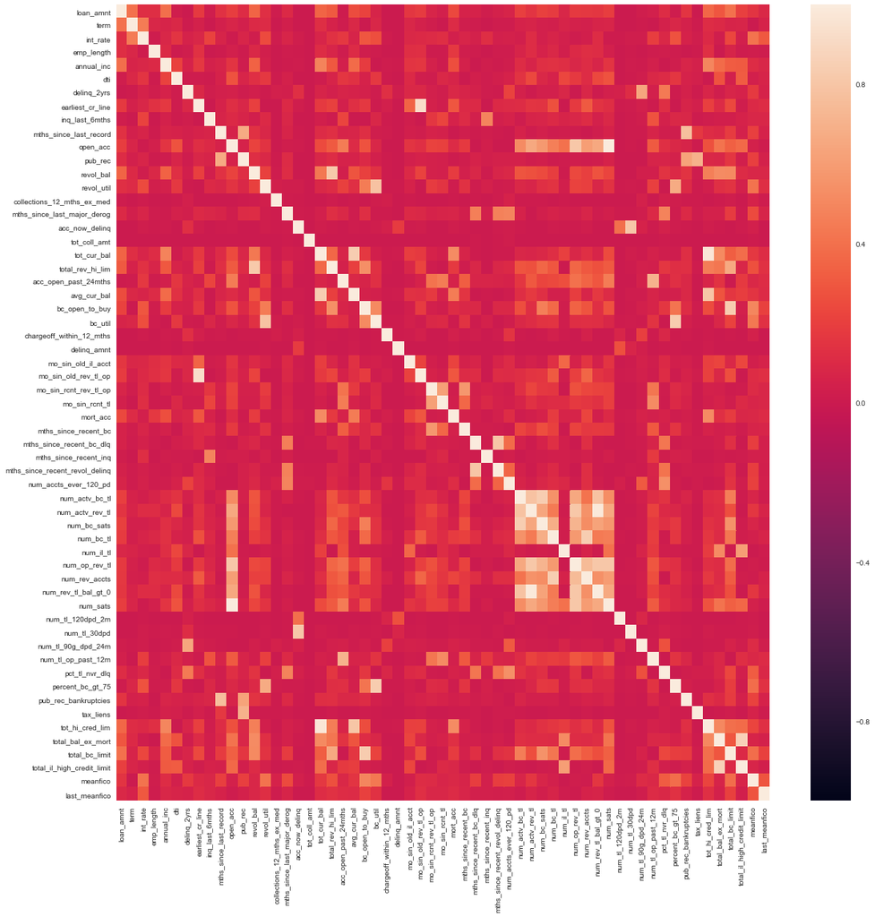

```python
# Plot the heatmap of correlation
fig, ax = plt.subplots(figsize=(20,20))
sns.heatmap(cor, xticklabels=cor.columns, yticklabels=cor.columns, vmin=-1, vmax=1)
```

Let's examin the relationship between interest rate and FICO score

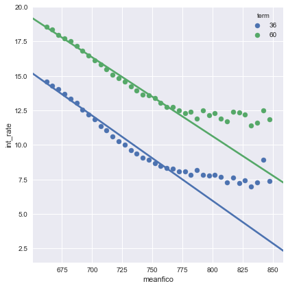

```python
sns.set(color_codes=True)
sns.lmplot(x="meanfico", y="int_rate", data=orig_df,  x_estimator=np.mean, ci = None, hue = "term", size = 6,
          legend_out=False);
```

Let's get our data out of the object data type land, into a numeric type, since nearly all operations we'd like to apply to our data are going to rely on numeric types

```python
df = orig_df.copy()
df.shape
df.drop(['issue_d','fico_range','last_fico_range','grade'],1,inplace = True)
```

```python
df = pd.get_dummies(df)
```

```python
df.shape
```

```
(235629, 131)
```

## Model Evaluation

```python
from sklearn.pipeline import Pipeline
from sklearn import cross_validation
from sklearn.model_selection import cross_val_score
from sklearn.cross_validation import KFold, StratifiedKFold, train_test_split
from sklearn.svm import SVR
from sklearn.decomposition import PCA
from sklearn.pipeline import make_pipeline
from sklearn import ensemble
from sklearn import datasets
from sklearn.utils import shuffle
from sklearn.metrics import mean_squared_error
from matplotlib import pyplot as plt
from sklearn import ensemble
from sklearn.preprocessing import StandardScaler, RobustScaler
import pickle
from pprint import pprint
from yellowbrick.regressor import PredictionError
from sklearn.discriminant_analysis import LinearDiscriminantAnalysis as LDA

def regression_model_selection(X, y, model_estimator, model_label, feature_selection = False):
    """
    Test various estimators.
    """

    if feature_selection :
        models = []
        #by default PCA only rotates and shifts the data, but keeps all principal components. To reduce dimensionality we need to specify how many components we want to keep
        model_1 = Pipeline(steps = [ ('StandardScaler', StandardScaler()),('PCA', PCA(n_components = 2)), ('estimator', model_estimator) ])
        models = [['StandardScaler with PCA',model_1]]

    else :
        model_1 = model_estimator
        model_2 = Pipeline([ ('StandardScaler', StandardScaler()), ('estimator', model_estimator) ])
        model_3 = Pipeline([ ('RobustScaler', RobustScaler()), ('estimator', model_estimator) ])
        models = [['No Scaler',model_1], ['StandardScaler',model_2], ['RobustScaler',model_3]]


    for model_to_run in models :
        scaler = model_to_run[0]
        model = model_to_run[1]

        X_train, X_test, y_train, y_test = train_test_split(X, y, test_size=0.33)

        #Instantiate the visualizer
        visualizer = PredictionError(model)

        # Fit
        visualizer.fit(X_train, y_train)
        # Score and visualize
        visualizer.score(X_test, y_test)

        print("{} after {}".format(model_label,scaler))

        visualizer.poof()


        model.fit(X_train, y_train)

        expected  = y_test
        predicted = model.predict(X_test)

        # Compute MSE
        print (mean_squared_error(expected, predicted))

        #pprint(pd.DataFrame(scores).mean())
```

```python
## Let's define our predictors
y = df['int_rate'].values
X = df.copy()
X.drop('int_rate',axis = 1, inplace=True)
```

```
RidgeCV after No Scaler
```

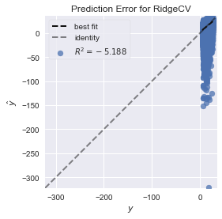

```
RidgeCV after StandardScaler
```

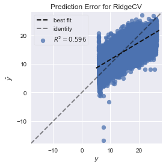

```
RidgeCV after RobustScaler
```

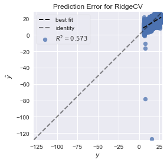

```python
from sklearn.linear_model import RidgeCV
regression_model_selection(X,y,RidgeCV(),'RidgeCV')
```

```
LinearRegression after No Scaler
```

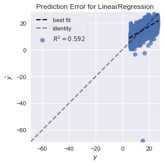

```
LinearRegression after StandardScaler
```

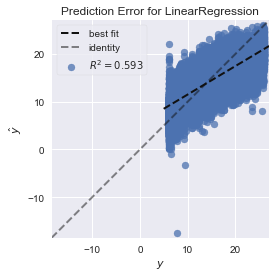

```
LinearRegression after RobustScaler
```

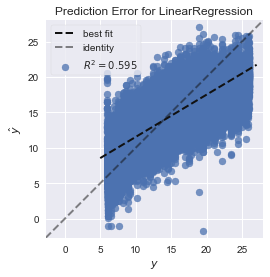

```python
regression_model_selection(X,y,LinearRegression(),'LinearRegression')
```

```
LassoCV after No Scaler
```

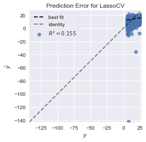

```
LassoCV after StandardScaler
```

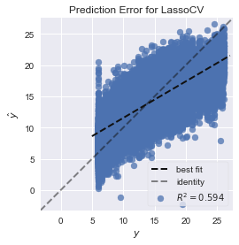

```
LassoCV after RobustScaler
```

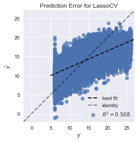

```python
from sklearn.linear_model import LassoCV
regression_model_selection(X,y,LassoCV(), 'LassoCV')
```

```
ElasticNetCV after No Scaler
```

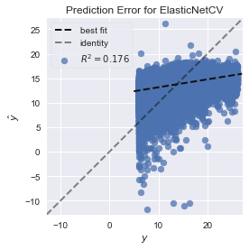

```
ElasticNetCV after StandardScaler
```

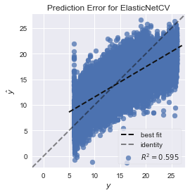

```
ElasticNetCV after RobustScaler
```

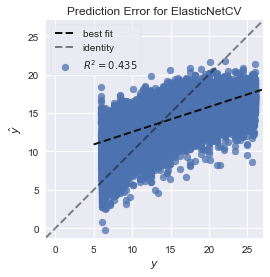

```python
from sklearn.linear_model import ElasticNetCV
regression_model_selection(X,y,ElasticNetCV(), 'ElasticNetCV')
```

```
RandomForestRegressor after No Scaler
```

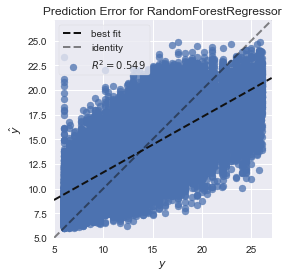

```
RandomForestRegressor after StandardScaler
```

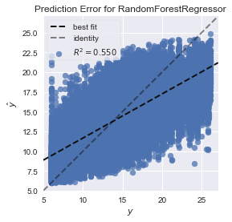

```
RandomForestRegressor after RobustScaler
```

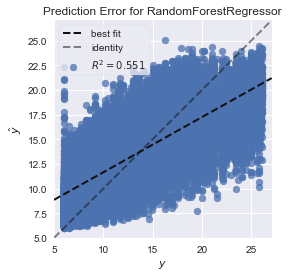

```python
from sklearn.ensemble import RandomForestRegressor

y = df['int_rate'].values
X = df.copy()
X.drop(['int_rate','meanfico'],axis = 1, inplace=True)
regression_model_selection(X,y,RandomForestRegressor(), 'RandomForestRegressor')
```

```
GradientBoostingRegressor after No Scaler
```

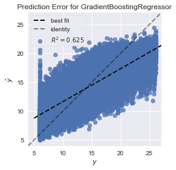

```
GradientBoostingRegressor after StandardScaler
```

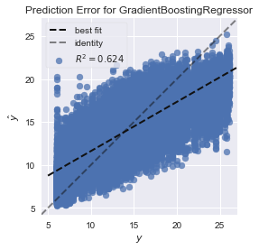

```
GradientBoostingRegressor after RobustScaler
```

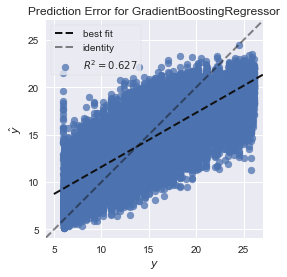

```python
y = df['int_rate'].values
X = df.copy()
X.drop(['int_rate'],axis = 1, inplace=True)
regression_model_selection(X,y,ensemble.GradientBoostingRegressor(), 'GradientBoostingRegressor')
```

We notice that GradientBoostingRegressor() is performing better than the other models!

### Dimensionality Reduction

```
GradientBoostingRegressor after StandardScaler with PCA
```

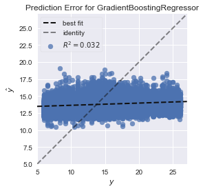

```python
y = df['int_rate'].values
X = df.copy()
X.drop(['int_rate'],axis = 1, inplace=True)
regression_model_selection(X,y,ensemble.GradientBoostingRegressor(), 'GradientBoostingRegressor', True)
```

### Grid Search

Let's do a grid search to find optimal hyperparameter

```python
from sklearn.grid_search import GridSearchCV

X_train, X_test, y_train, y_test = train_test_split(X, y, test_size=0.2)

param_grid = {'learning_rate': [0.1, 0.05, 0.02, 0.01],
              'max_depth': [4, 6],
              'min_samples_leaf': [3, 5, 9, 17],
              'max_features': [1.0, 0.3, 0.1]
              }

est = GridSearchCV(ensemble.GradientBoostingRegressor(n_estimators=100),
                   param_grid, n_jobs=4, refit=True)

est.fit(X_train, y_train)

best_params = est.best_params_
```

```python
est = ensemble.GradientBoostingRegressor(n_estimators=2000).fit(X_train, y_train)
est.score(X_test,y_test)
```

```python
y = df['int_rate'].values
X = df.copy()
X.drop(['int_rate'],axis = 1, inplace=True)
regression_model_selection(X,y,ensemble.GradientBoostingRegressor(learning_rate = 0.1, max_depth = 6, max_features = 1.0, min_samples_leaf = 3),'hyperparameter tuning')
```

[output not shown]

Let's plot the twenty most important variables for GBR

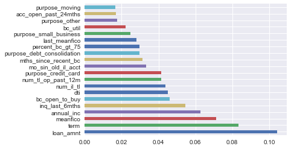

```python
def plot_GB_important_features():

    model = ensemble.GradientBoostingRegressor()
    #Instantiate the model
    model.fit(X, y)

    #Plot 10 most important features
    feat_importances = pd.Series(model.feature_importances_, index=X.columns)
    feat_importances = feat_importances.nlargest(20)
    feat_importances.plot(kind='barh')

plot_GB_important_features()
```

Let's try with the variables we have on the report, that are user freindly

```python
X = orig_df[['loan_amnt', 'term', 'int_rate', 'emp_length', 'home_ownership', 'annual_inc', 'purpose', 'meanfico','revol_util','inq_last_6mths','dti','delinq_2yrs']]
X = pd.get_dummies(X)
X.drop(['int_rate'],axis = 1, inplace=True)
y = orig_df['int_rate']
```

```
GradientBoostingRegressor after No Scaler
```

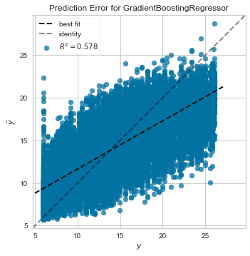

```
7.884588149086946
GradientBoostingRegressor after StandardScaler
```

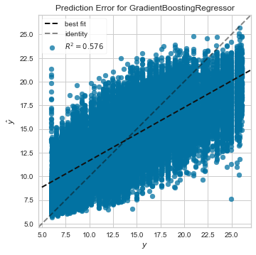

```
7.929693583431342
GradientBoostingRegressor after RobustScaler
```

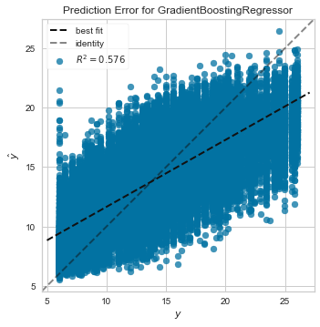

```
7.913282439842287
```

```python
regression_model_selection(X,y,ensemble.GradientBoostingRegressor(learning_rate = 0.1, max_depth = 6, max_features = 1.0, min_samples_leaf = 3),'GradientBoostingRegressor')
```